# Exam 3

0316213 蒲郁文

2018-06-19

```r
knitr::opts_chunk$set(results = "hold", fig.retina = 2)
set.seed(1830)
```

##### 1.1

```r
d <- matrix(c(29, 16, 55, 198, 107, 181), byrow = TRUE, nrow = 2)
d
chisq.test(d, correct = FALSE)
```

```
##      [,1] [,2] [,3]
## [1,]   29   16   55
## [2,]  198  107  181
##
##  Pearson's Chi-squared test
##
## data:  d
## X-squared = 10.875, df = 2, p-value = 0.004351
```

是，p 值小於 0.05，表示兩事件不獨立。

##### 1.2

因為 `3+ cycles` 的數量有點多，我會把 `3+ cycles` 拆成 `3 cycles` 與 `4+ cycles`。

##### 1.3

```r
e <- d * 2
e
chisq.test(e, correct = FALSE)
```

```
##      [,1] [,2] [,3]
## [1,]   58   32  110
## [2,]  396  214  362
##
##  Pearson's Chi-squared test
##
## data:  e
## X-squared = 21.75, df = 2, p-value = 1.893e-05
```

X^2 變大，p 值變小。

##### 1.4

資料量愈大愈顯著。

##### 2.1

```r
d <- read.table("E02.dat", header = TRUE, sep = "")
d$Percent <- d$Down / d$Births * 100
head(d)
```

```
##    Age Births Down    Percent
## 1 17.5  13555   16 0.11803762
## 2 18.5  13675   15 0.10968921
## 3 19.5  18752   16 0.08532423
## 4 20.5  22005   22 0.09997728
## 5 21.5  23796   16 0.06723819
## 6 22.5  24667   12 0.04864799
```

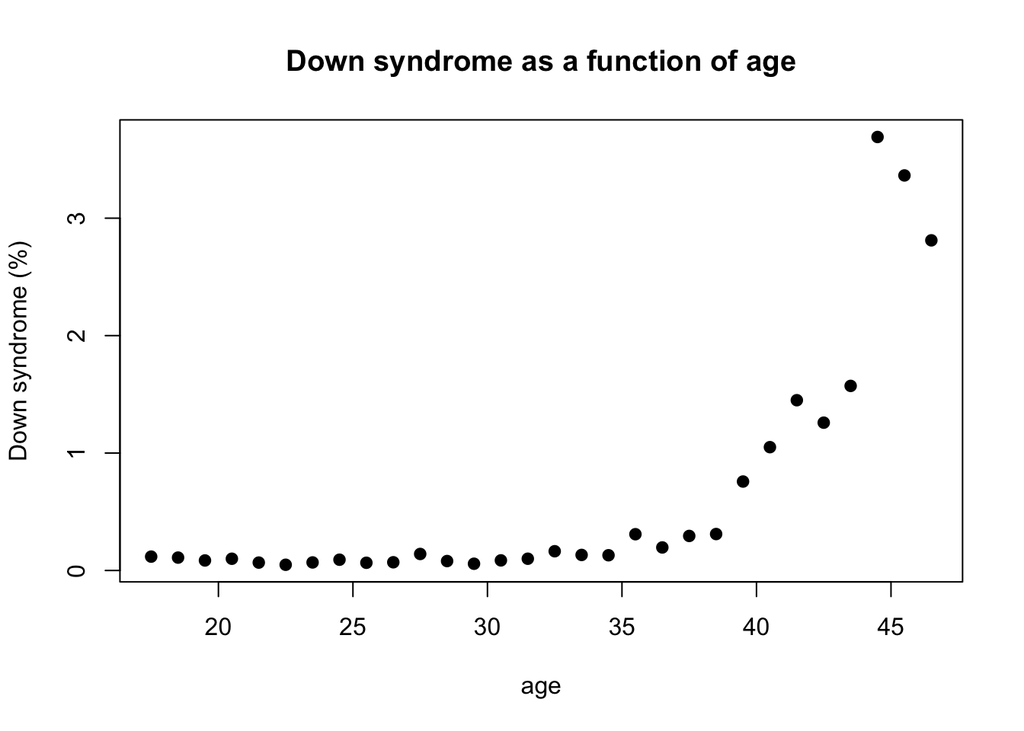

```r
plot(d$Age, d$Percent, main = "Down syndrome as a function of age",
     xlab = "age", ylab = "Down syndrome (%)", pch = 19)
```

##### 2.2

它是曲線上升，在 35 歲以前沒有明顯的上升趨勢。

##### 2.3

```r
d$Rank <- rank(d$Percent)
head(d)
```

```
##    Age Births Down    Percent Rank
## 1 17.5  13555   16 0.11803762   14
## 2 18.5  13675   15 0.10968921   13
## 3 19.5  18752   16 0.08532423    8
## 4 20.5  22005   22 0.09997728   11
## 5 21.5  23796   16 0.06723819    4
## 6 22.5  24667   12 0.04864799    1
```

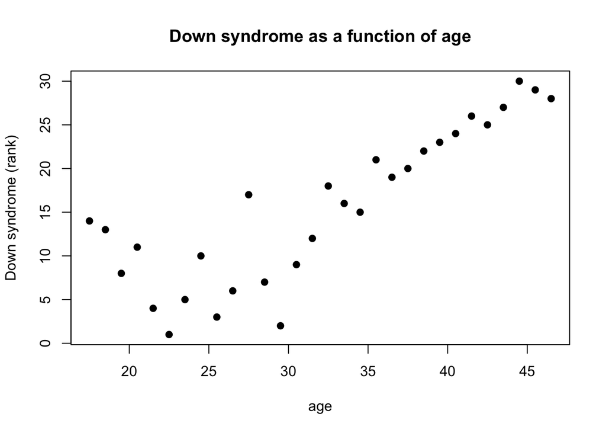

```r
plot(d$Age, d$Rank, main = "Down syndrome as a function of age",
     xlab = "age", ylab = "Down syndrome (rank)", pch = 19)
```

```r
cor(d$Age, d$Rank)
```

```
## [1] 0.8451613
```

是，這是 Spearman’s correlation。

##### 3.1 & 3.2

```r
d <- read.table("E03.dat", header = TRUE, sep = "")
head(d)
```

```
##   Sex Height Weight
## 1   1     70    150
## 2   1     67    140
## 3   1     72    180
## 4   1     75    190
## 5   1     68    145
## 6   1     69    150
```

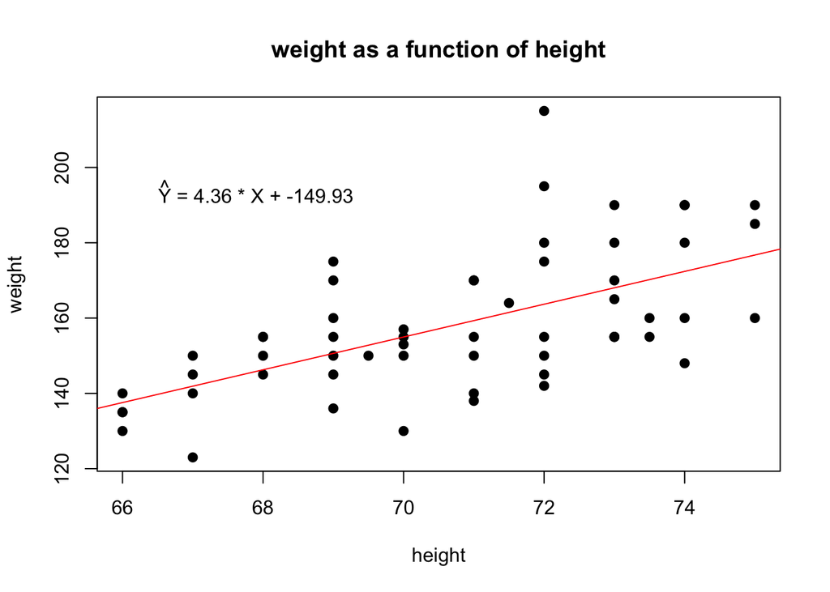

```r
plot(d$Height, d$Weight, main = "weight as a function of height",
     xlab = "height", ylab = "weight", pch = 19)
abline(lm(d$Weight ~ d$Height), col = "red")
regress <- lm(d$Weight ~ d$Height)
b <- round(regress$coefficients[["d$Height"]], digits = 2)
a <- round(regress$coefficients[["(Intercept)"]], digits = 2)
legend(66, 200, substitute(
        paste(hat(Y), " = ", b, " * X + ", a),
        list(b = b, a = a)
    ), bty = "n")
```

身高每增加一單位，體重就會增加 4.36 單位。  
截距沒有特殊意義，只是用來平移迴歸線，使預測值的平均等於觀察到的體重的平均。

##### 3.3 & 3.4

```r
cor.test(d$Height, d$Weight)
```

```
##
##  Pearson's product-moment correlation
##
## data:  d$Height and d$Weight
## t = 5.6157, df = 55, p-value = 6.661e-07
## alternative hypothesis: true correlation is not equal to 0
## 95 percent confidence interval:
##  0.4071576 0.7467793
## sample estimates:
##       cor
## 0.6036796
```

相關係數為 0.6036796。是的，p 值小於 0.05。  
（當只有一個 predictor 時，對相關係數的檢定與對斜率的檢定，結果是一樣的。）

##### 4.1 & 4.2

```r
d <- read.table("E04.dat", header = TRUE, sep = "")
head(d)
```

```
##   Sex Height Weight
## 1   2     61    140
## 2   2     66    120
## 3   2     68    130
## 4   2     68    138
## 5   2     63    121
## 6   2     70    125
```

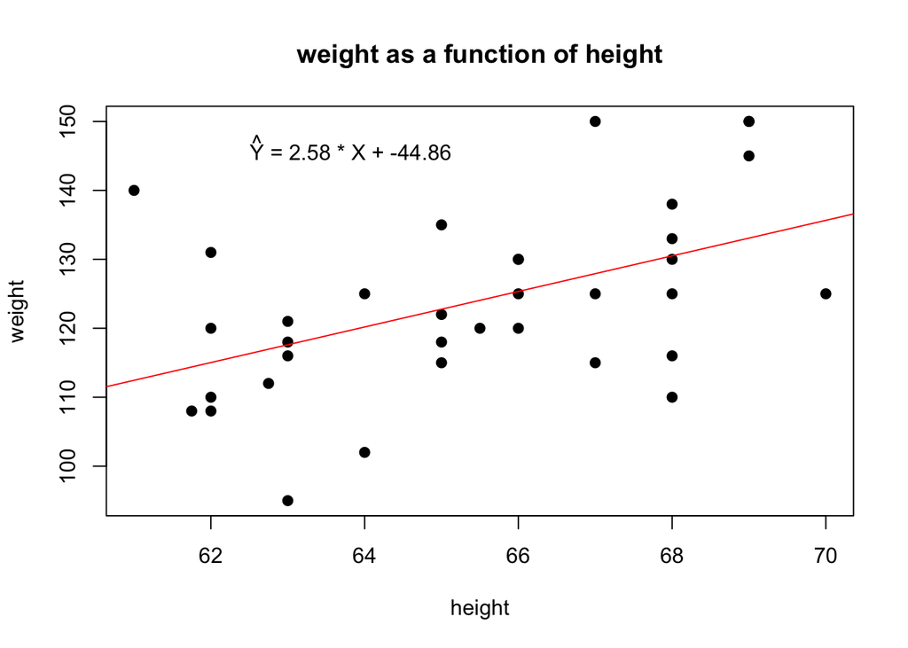

```r
plot(d$Height, d$Weight, main = "weight as a function of height",
     xlab = "height", ylab = "weight", pch = 19)
abline(lm(d$Weight ~ d$Height), col = "red")
regress <- lm(d$Weight ~ d$Height)
b <- round(regress$coefficients[["d$Height"]], digits = 2)
a <- round(regress$coefficients[["(Intercept)"]], digits = 2)
legend(62, 150, substitute(
        paste(hat(Y), " = ", b, " * X + ", a),
        list(b = b, a = a)
    ), bty = "n")
```

身高每增加一單位，體重就會增加 2.58 單位。  
截距沒有特殊意義，只是用來平移迴歸線，使預測值的平均等於觀察到的體重的平均。

##### 4.3 & 4.4

```r
cor.test(d$Height, d$Weight)
```

```
##
##  Pearson's product-moment correlation
##
## data:  d$Height and d$Weight
## t = 3.2657, df = 33, p-value = 0.002548
## alternative hypothesis: true correlation is not equal to 0
## 95 percent confidence interval:
##  0.1927037 0.7104518
## sample estimates:
##       cor
## 0.4942129
```

相關係數為 0.4942129。是的，p 值小於 0.05。  
（當只有一個 predictor 時，對相關係數的檢定與對斜率的檢定，結果是一樣的。）

##### 5.1

```r
y_hat <- 4.36 * 71 + -149.93
cat("predicted:", y_hat, fill = TRUE)
cat("residual:", 166 - y_hat, fill = TRUE)
```

```
## predicted: 159.63
## residual: 6.37
```

##### 5.2

可能是年齡造成的誤差。學生的年齡與被預測者不同，而年齡可能也會影響體重。

##### 6.1 & 6.2

```r
d <- read.table("E06.dat", header = TRUE, sep = "")
d
```

```
##   HoursTV Girls Boys
## 1       0   258  276
## 2       1   269  273
## 3       2   267  292
## 4       3   261  269
## 5       4   259  266
## 6       5   253  259
## 7       6   239  249
```

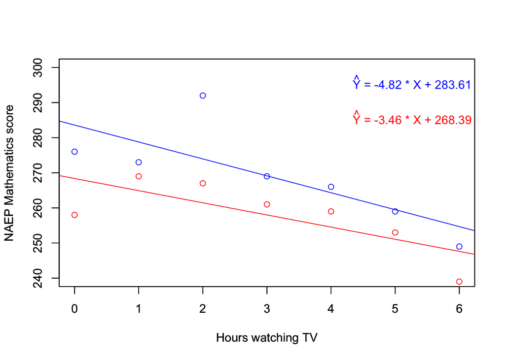

```r
plot(d$Boys ~ d$HoursTV, ylim = c(240, 300), col = "blue", xlab = "Hours watching TV",
     ylab = "NAEP Mathematics score")
abline(lm(d$Boys ~ d$HoursTV), col = "blue")

regress <- lm(d$Boys ~ d$HoursTV)
b <- round(regress$coefficients[["d$HoursTV"]], digits = 2)
a <- round(regress$coefficients[["(Intercept)"]], digits = 2)
legend(4, 300, substitute(
        paste(hat(Y), " = ", b, " * X + ", a),
        list(b = b, a = a)
    ), bty = "n", text.col = "blue")

par(new = TRUE)

plot(d$Girls ~ d$HoursTV, ylim = c(240, 300), col = "red", xlab = "Hours watching TV",
     ylab = "NAEP Mathematics score")
abline(lm(d$Girls ~ d$HoursTV), col = "red")

regress <- lm(d$Girls ~ d$HoursTV)
b <- round(regress$coefficients[["d$HoursTV"]], digits = 2)
a <- round(regress$coefficients[["(Intercept)"]], digits = 2)
legend(4, 290, substitute(
        paste(hat(Y), " = ", b, " * X + ", a),
        list(b = b, a = a)
    ), bty = "n", text.col = "red")
```

藍色代表男生，紅色代表女生。

對男生而言，觀看電視的時間每增加一單位，數學成績就會減少 4.82 單位。  
對女生而言，觀看電視的時間每增加一單位，數學成績就會減少 3.46 單位。  
截距沒有特殊意義，只是用來平移迴歸線，使預測值的平均等於觀察到的數學成績的平均。

##### 6.3

不行。依據以上分析，觀看電視的時間與數學成績呈負相關；假如男生觀看電視的時間比女生更久，那麼男生的數學成績應該比女生差。可是依據以上資料，男生的數學成績高於女生。

##### 7.1

```r
d <- read.table("E07.dat", header = TRUE, sep = "")
head(d)
```

```
##   Sex Height Weight
## 1   1   66.0    140
## 2   1   72.0    145
## 3   1   73.5    160
## 4   1   73.0    190
## 5   1   69.0    155
## 6   1   73.0    165
```

```r
model1 <- lm(d$Weight ~ d$Height)
model2 <- lm(d$Weight ~ d$Height + d$Sex)
```

```r
summary(model1)
summary(model2)
```

```
##
## Call:
## lm(formula = d$Weight ~ d$Height)
##
## Residuals:
##     Min      1Q  Median      3Q     Max
## -31.499 -11.339  -1.132   8.615  53.134
##
## Coefficients:
##              Estimate Std. Error t value Pr(>|t|)
## (Intercept) -204.7408    29.1597  -7.021 4.02e-10 ***
## d$Height       5.0918     0.4237  12.016  < 2e-16 ***
## ---
## Signif. codes:  0 '***' 0.001 '**' 0.01 '*' 0.05 '.' 0.1 ' ' 1
##
## Residual standard error: 14.79 on 90 degrees of freedom
## Multiple R-squared:  0.616,  Adjusted R-squared:  0.6117
## F-statistic: 144.4 on 1 and 90 DF,  p-value: < 2.2e-16
##
##
## Call:
## lm(formula = d$Weight ~ d$Height + d$Sex)
##
## Residuals:
##     Min      1Q  Median      3Q     Max
## -25.479  -8.591  -1.401   7.987  52.139
##
## Coefficients:
##             Estimate Std. Error t value Pr(>|t|)
## (Intercept) -88.1989    43.7774  -2.015 0.046953 *
## d$Height      3.6911     0.5723   6.450 5.67e-09 ***
## d$Sex       -14.6996     4.2900  -3.426 0.000927 ***
## ---
## Signif. codes:  0 '***' 0.001 '**' 0.01 '*' 0.05 '.' 0.1 ' ' 1
##
## Residual standard error: 13.98 on 89 degrees of freedom
## Multiple R-squared:  0.6608, Adjusted R-squared:  0.6531
## F-statistic: 86.68 on 2 and 89 DF,  p-value: < 2.2e-16
```

在多重迴歸中，體重仍然會隨著身高的增加而增加，但增加的幅度沒有那麼大了。  
（在性別不變的情況下，身高每增加一單位，體重只會增加 3.6911 單位。）  
「性別」的迴歸係數將近 -15，表示在身高不變的情況下，「性別」欄位由 1（男性）轉變為 2（女性），體重就會降低 15 單位左右。可見女性的體重普遍低於男性。

##### 7.2

```r
d_male <- d[d$Sex == "1", ]
d_female <- d[d$Sex == "2", ]
model_male <- lm(d_male$Weight ~ d_male$Height)
model_female <- lm(d_female$Weight ~ d_female$Height)
```

```r
summary(model_male)
summary(model_female)
```

```
##
## Call:
## lm(formula = d_male$Weight ~ d_male$Height)
##
## Residuals:
##     Min      1Q  Median      3Q     Max
## -24.977 -12.401  -1.265   8.735  51.311
##
## Coefficients:
##                Estimate Std. Error t value Pr(>|t|)
## (Intercept)   -149.9336    54.9169  -2.730  0.00849 **
## d_male$Height    4.3559     0.7757   5.616 6.66e-07 ***
## ---
## Signif. codes:  0 '***' 0.001 '**' 0.01 '*' 0.05 '.' 0.1 ' ' 1
##
## Residual standard error: 14.99 on 55 degrees of freedom
## Multiple R-squared:  0.3644, Adjusted R-squared:  0.3529
## F-statistic: 31.54 on 1 and 55 DF,  p-value: 6.661e-07
##
##
## Call:
## lm(formula = d_female$Weight ~ d_female$Height)
##
## Residuals:
##      Min       1Q   Median       3Q      Max
## -22.6107  -5.9461  -0.7684   4.8893  27.5471
##
## Coefficients:
##                 Estimate Std. Error t value Pr(>|t|)
## (Intercept)     -44.8589    51.6835  -0.868  0.39169
## d_female$Height   2.5789     0.7897   3.266  0.00255 **
## ---
## Signif. codes:  0 '***' 0.001 '**' 0.01 '*' 0.05 '.' 0.1 ' ' 1
##
## Residual standard error: 11.8 on 33 degrees of freedom
## Multiple R-squared:  0.2442, Adjusted R-squared:  0.2213
## F-statistic: 10.67 on 1 and 33 DF,  p-value: 0.002548
```

##### 7.3

```r
weighted_slope <- (dim(d_male)[1] * model_male$coefficients[["d_male$Height"]] +
                   dim(d_female)[1] * model_female$coefficients[["d_female$Height"]]) /
                  (dim(d_male)[1] + dim(d_female)[1])
dim(d_male)[1] + dim(d_female)[1] == dim(d)[1]
weighted_slope
```

```
## [1] TRUE
## [1] 3.679841
```

加權平均後的斜率（3.67984）非常接近多重迴歸中身高的迴歸係數（3.6911）。  
這樣的結果符合預期，因為這兩種計算迴歸係數的方法都有控制性別。